# meeting_with_pp

## Cannot Fit a Tomb-level Model

- **Small number of tombs**: Amfissa and 7 tombs from Elateia
- For too many parameters: length of use, # analysed individuals, effect of 4 types of skeletal elements

$\Rightarrow$ **With the available data, a meaningful tomb-level model is not possible**

**Can still summarize and visualize the data.**

## Evidence against MNI-based inference

**Note**

With the tomb-level model out of the question, whether we use MNI-based or sample-based inference is irrelevant to our methodology.  
The only difference is how to interpret those results.

## Evidence against MNI-based inference

- **The assumption is acknowledged as a simplification**  
  [Royal Society B article](https://royalsocietypublishing.org/rstb/article/376/1816/20190719/31363/Sometimeshidden-but-always-there-the-assumptions)
  3. Sampling bias
- **Kinship determines burial context**  
  [Science article](https://www.science.org/doi/10.1126/science.aax6219)
- **Burial context determines preservation**  
  [JSTOR article](https://www.jstor.org/stable/280601)

**True Kinship -> Burial context -> Preservation -> Data quality -> Being sampled -> Observed kinship**

$\Rightarrow$ Can not work with the assumption that kinship is not independent of the preservation/sampling

$\Rightarrow$ Have to clearly state in the report as a limitation

## Why bone quality variables are excluded

- The preservation bias is already taken care of from when we apply 15k threshold
- Adding them (skeletal element & OSNP) would not contribute anything further to the model but would only make the numerical fitting process harder

## DAG (**Directed acyclic graph)**

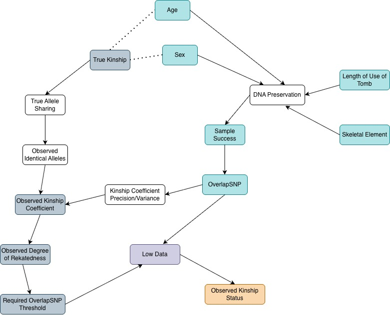

## Cross and within tomb relations

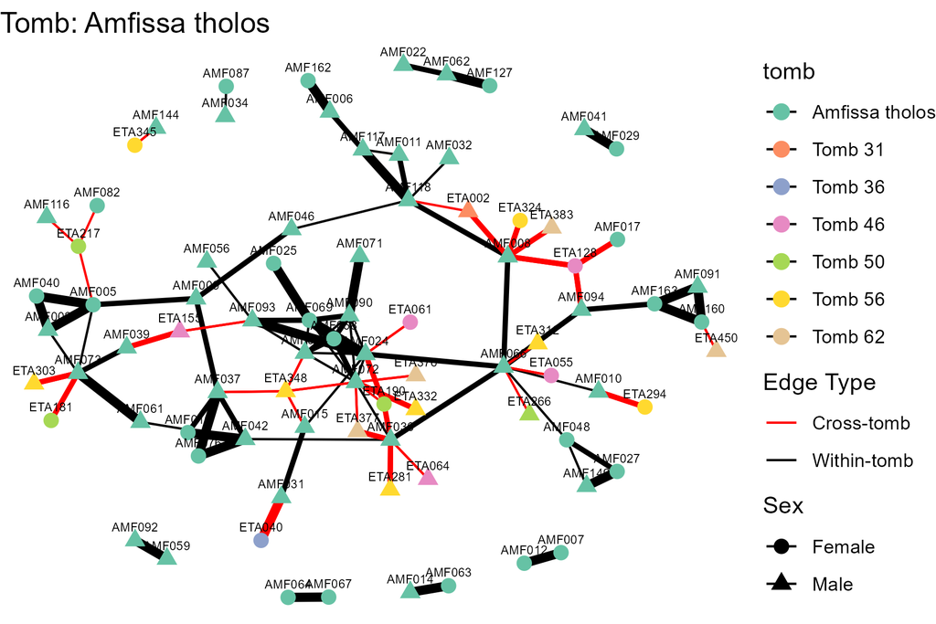

## Cross and within tomb relations

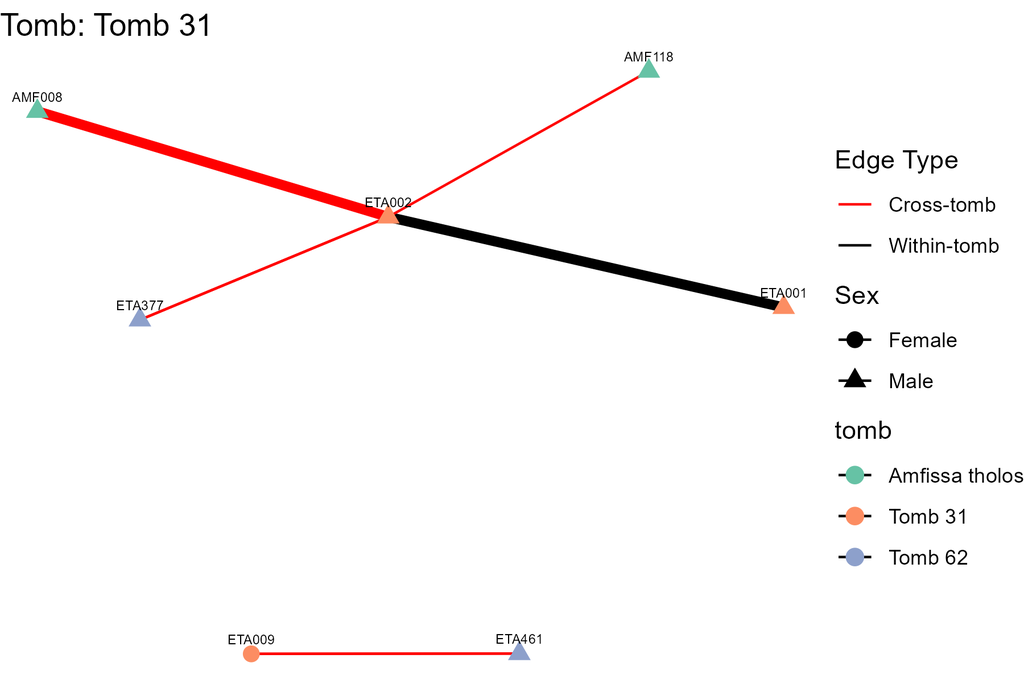

## Cross and within tomb relations

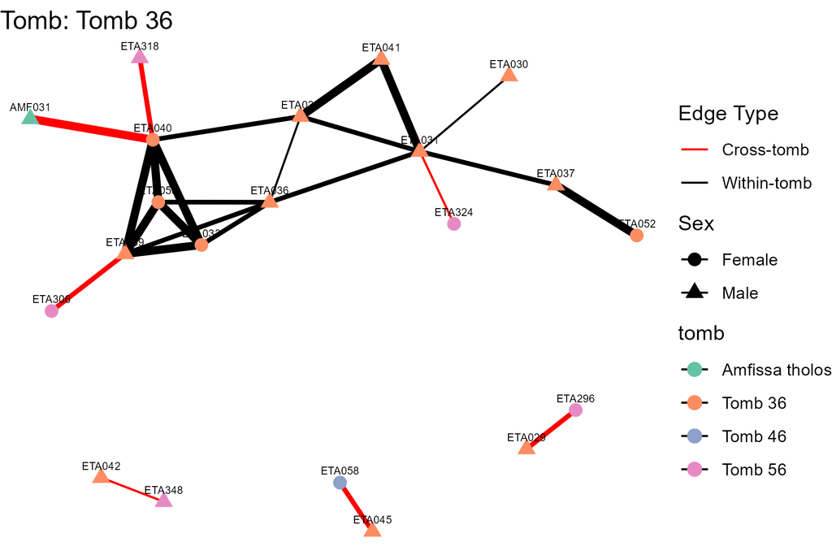

## Cross and within tomb relations

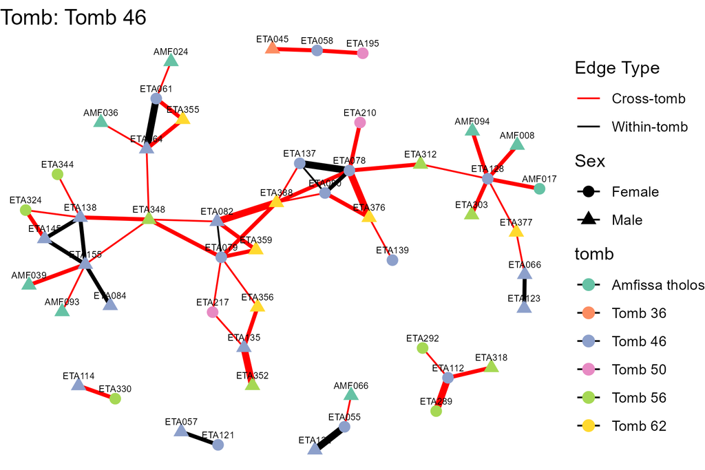

## Cross and within tomb relations

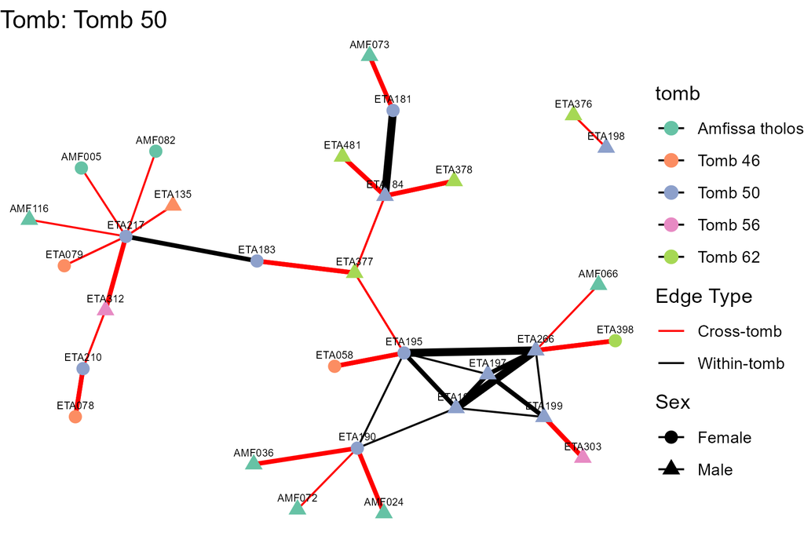

## Cross and within tomb relations

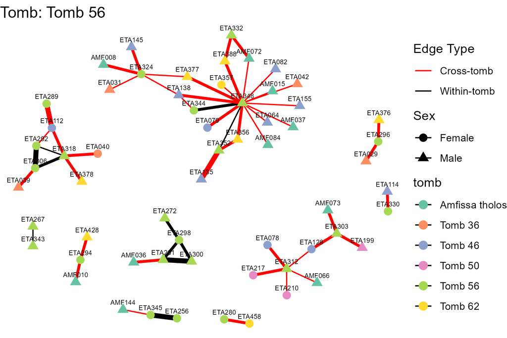

## Cross and within tomb relations

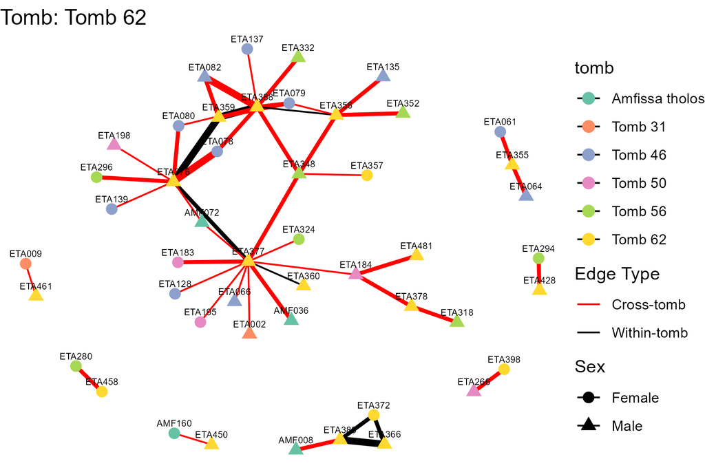

## Cross and within tomb relations

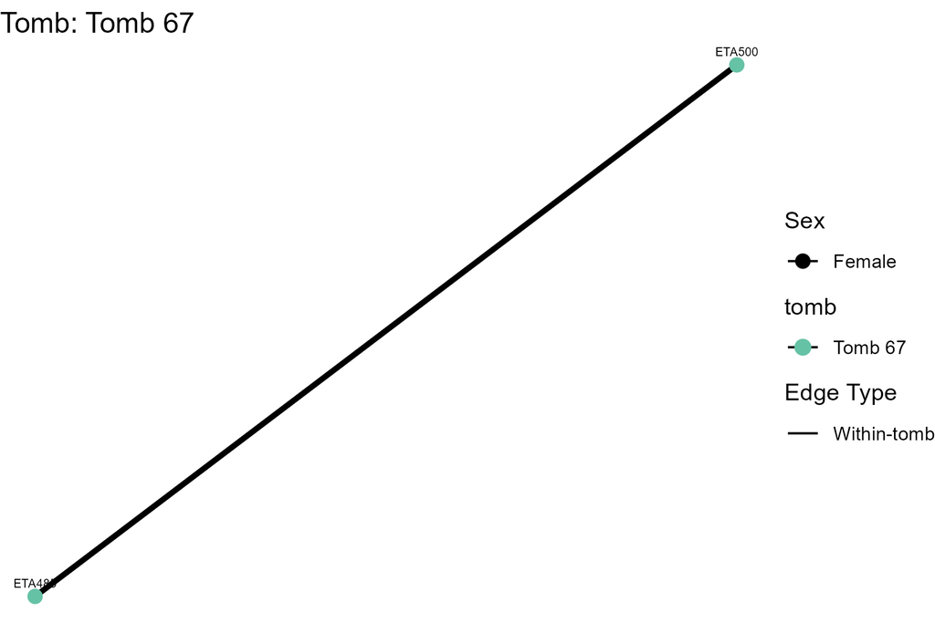

## Cross and within tomb relations

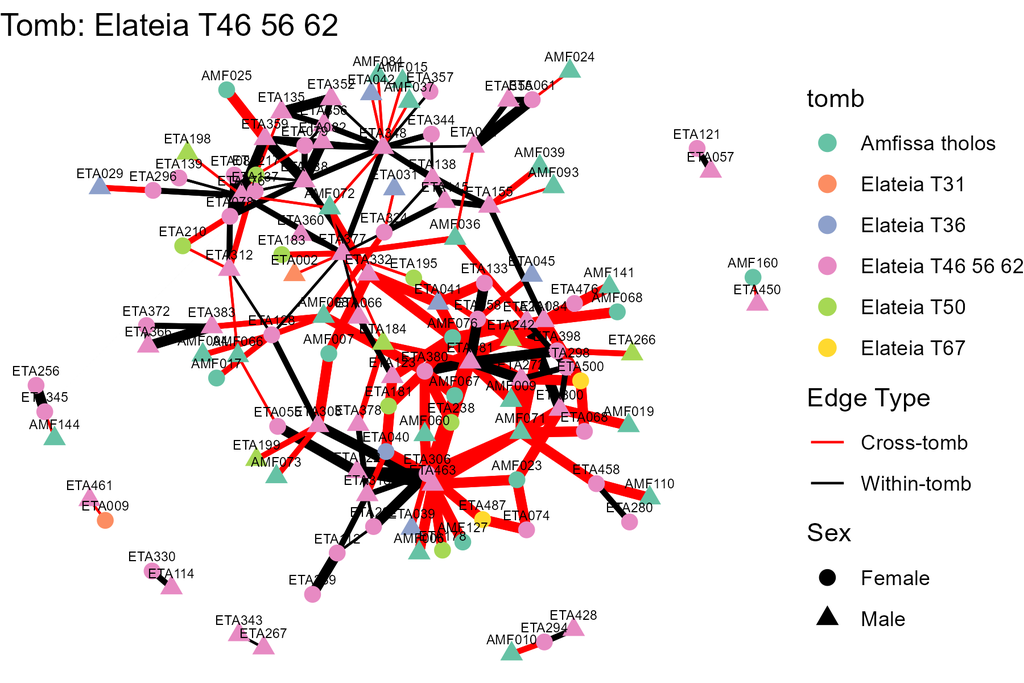